# Introducción a funciones

## Definición de función

En la sección de algoritmos tuvimos un acercamiento a la noción de función, de hecho, vimos que las funciones en Python toman un lugar valioso porque reducen la necesidad de crear rutinas varias veces que van a hacer los mismos desarrollos. Teniendo en cuenta esa definición podemos estudiar la definición formal de este concepto, que aunque fundamenta mucho de lo que vimos en Python no resulta equivalente:

[figure not shown]

El video siguiente nos aclara esta definción y nos motiva a ver algunos resultados más:

[figure not shown]

Veamos algunos ejemplos:

**Ejemplo1**

[figure not shown]

Respuesta a la pregunta propuesta:

Porque no contradice la definición de función, donde cada elemento del conjunto de partida se le permite una sola imagen.

**Ejemplo 2**

[figure not shown]

Respuesta a la pregunta propuesta:

Porque contradice la definición de función, hay un elemento del conjunto de partida que tiene dos imágenes.

**Ejemplo 3**

[figure not shown]

Solución:

[figure not shown]

Usemos Python:

```python
import numpy as np ## Importamos este paquete para usar la raíz (sqrt)
def h(x):
    h=np.sqrt(x+4)
    return h
```

```python
## Creamos la lista con los valores solicitados
valores=[0,3,-2,-8,-10]

## imprimimos los resultados
for i in valores:
    print("h("+str(i)+")=",h(i))
```

```
h(0)= 2.0
h(3)= 2.6457513110645907
h(-2)= 1.4142135623730951
h(-8)= nan
h(-10)= nan
```

[figure not shown]

### Ejercicio

[figure not shown]

## Función lineal

[figure not shown]

### Programa para funciones lineales

Construya un programa que reciba la pendiente y un punto y grafique la respectiva recta.

```python
import sympy as sp
import numpy as np
import matplotlib.pyplot as plt
from sympy import Symbol
#x=Symbol("x")
def punto_pendiente(m,x1,y1):
    m,x1,y1=float(m),float(x1),float(y1)
    b=(-m*x1+y1)

    if b>0:
        print("La ecuación de la recta es y = {m}x + {b}, \nY su representación gráfica es: ".format(m=m,b=b))
    elif b<0:
        print("La ecuación de la recta es y = {m}x{b} \nY su representación gráfica es:".format(m=m,b=b))
    else:
        print("La ecuación de la recta es y = {m}x \nY su representación gráfica es:".format(m=m,b=b))
    x = np.linspace(-4,4,10000)
    y = m*x+b
    plt.plot(x, y, '-b',label='y')
    plt.title('Gráfica de la ecuación de la recta')
    plt.xlabel('x', color='b')
    plt.ylabel('y', color='b')
    plt.legend(loc='upper left')
    plt.grid()
    plt.show()
```

### Ejemplo

Determine la gráfica de la recta que tiene pendiente -2 y pasa por el punto (0,3).

```
La ecuación de la recta es y = -2.0x + 3.0,
Y su representación gráfica es:
```

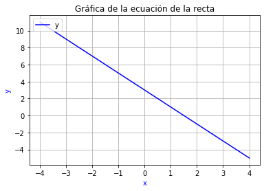

```python
punto_pendiente(-2,0,3)
```